# Microbiome analytics Report: Biogeography_communities

Sudarshan

2017-12-23

# Microbiome analytics tool

Reproducibilty is an essential aspect of data analysis. Especially for sequencing data for microbial community profilling. There are lack of standards to analysing and reporting data. This is mostly because there are simply some aspects of the data that we do not control. In such cases it is important to have rational decision making and documenting it. In almost all microbiome profilling data choices regarding filtering parameters (OTU count, OTU prevalences), normalisation, transformation are routine practice. Pre-processing is an essential step and it is crucial that it is documented. There are some common approaches to look at the data.  
1. How many reads/samples? if there is large difference this may affect the choices you make for alpha diversity, betadiversity and differential abundance testing. 2. How many reads/OTU ? this is aslo important to see if there are lot of OTUs with small mean & large coefficient of variation (C.V.).

This tempate for microbiome data analysis, handling and visualisation. This makes it easy to follow some standard procedures for looking at your data and reporting your results. This first-hand look at your data will aid in making different choices for more thorough and in-dept investigation.

Check this link on [Organize your data and code](http://kbroman.org/steps2rr/pages/organize.html).

You can find the source code at [microbiomeutilities github repo](https://github.com/microsud/microbiomeutilities).  
A step wise guide can be found at [microbiomeutilities wiki](https://github.com/microsud/microbiomeutilities/wiki).

## Set project attributes

Fill the details accordingly.

**Author :** Sudarshan

**Project :** Biogeography_communities

```r
#generate a random number
n <- runif(1, 0, 10^6) # keep this number stored as below instead of XXX when re running the codes.

message("random number set.seed is below")
```

```
## random number set.seed is below
```

```r
print(n)
```

```
## [1] 893774.8
```

```r
set.seed(n)
```

Check the code chunk next to this of left side to see folder names where files are stored.

```r
message("Working directory is ", work_dir)
```

```
## Working directory is F:/Duodenal_Fecal_Comp/duodenal_fecal_comparison/inputdata
```

```r
if(file.exists("QC")) {
  message("QC folder already exists, data will be overwritten")
} else{
  message("QC folder will be created in ", out_dir)
  dir.create(paste0(out_dir, "/QC"))
}
```

```
## QC folder will be created in F:/Duodenal_Fecal_Comp/duodenal_fecal_comparison/inputdata/myoutput
```

```r
if(file.exists("AlphaDiversity")) {
  message("AlphaDiversity folder already exists, data will be overwritten")
} else{
  message("AlphaDiversity folder will be created in ", out_dir)
  dir.create(paste0(out_dir, "/AlphaDiversity"))
}
```

```
## AlphaDiversity folder will be created in F:/Duodenal_Fecal_Comp/duodenal_fecal_comparison/inputdata/myoutput
```

```r
if(file.exists("BetaDiversity")) {
  message("BetaDiversity folder already exists, data will be overwritten")
} else{
  message("BetaDiversity folder will be created in ", out_dir)
  dir.create(paste0(out_dir, "/BetaDiversity"))
}
```

```
## BetaDiversity folder will be created in F:/Duodenal_Fecal_Comp/duodenal_fecal_comparison/inputdata/myoutput
```

```r
if(file.exists("Others")) {
  message("Others folder already exists, data will be overwritten")
} else{
  message("Others folder will be created in ", out_dir)
  dir.create(paste0(out_dir, "/Others"))
}
```

```
## Others folder will be created in F:/Duodenal_Fecal_Comp/duodenal_fecal_comparison/inputdata/myoutput
```

```r
if(file.exists("PhyloseqObjects")) {
  message("PhyloseqObjects folder already exists, data will be overwritten")
} else{
  message("PhyloseqObjects folder will be created in ", out_dir)
  dir.create(paste0(out_dir, "/PhyloseqObjects"))
}
```

```
## PhyloseqObjects folder will be created in F:/Duodenal_Fecal_Comp/duodenal_fecal_comparison/inputdata/myoutput
```

## Load libraries

We have to load libraries click on the code tab on the left hand die of this doc for looking at the libraries that are installed. It is good to install these packages before.

```r
library(microbiome)
library(microbiomeutilities)
# install.packages("picante",repos="http://R-Forge.R-project.org")
# library(picante)
library(picante)
library(data.table)
library(DT)
library(RColorBrewer)
library(phyloseq)
```

## Initiate

This code chunk reads the input files and creates a phyloseq object.

```r
ps0 <- read_phyloseq(otu.file = otufile,
                     metadata.file = mapping,
                     taxonomy.file = taxonomy,
                     type = "biom")
```

```
## Time to complete depends on OTU file size
```

```r
if (!is.na(treefilename)){
  tree <- read.tree(treefilename)

ps0 <- merge_phyloseq(ps0, tree)
} else{
  message("No tree available")
}
```

```
## No tree available
```

```r
saveRDS(ps0, paste0(out_dir, "/PhyloseqObjects/ps_raw.rds"))

message("Raw phyloseq object, confirm the number of samples and variables (as in columns of mapping file)")
```

```
## Raw phyloseq object, confirm the number of samples and variables (as in columns of mapping file)
```

```r
message("Below is the content of raw phyloseqobject stored as ps_raw.rds")
```

```
## Below is the content of raw phyloseqobject stored as ps_raw.rds
```

```r
print(ps0)
```

```
## phyloseq-class experiment-level object
## otu_table()   OTU Table:         [ 19063 taxa and 14 samples ]
## sample_data() Sample Data:       [ 14 samples by 20 sample variables ]
## tax_table()   Taxonomy Table:    [ 19063 taxa by 7 taxonomic ranks ]
```

## QC

```r
print("Below is the summary of the phyloseq object")
```

```
## [1] "Below is the summary of the phyloseq object"
```

```r
summarize_phyloseq(ps0)
```

```
## Compositional = NO
## 1] Min. number of reads = 175365
## 2] Max. number of reads = 452182
## 3] Total number of reads = 3504110
## 4] Average number of reads = 250293.571428571
## 5] Median number of reads = 222686
## 7] Sparsity = 0.85428766271236
## 6] Any OTU sum to 1 or less? YES
## 8] Number of singletons = 10759
## 9] Percent of OTUs that are singletons 56.439175365892
## 10] Number of sample variables are: 20
## study_accession
## sample_accession
## secondary_sample_accession
## experiment_accession
## run_accession
## tax_id
## scientific_name
## instrument_model
## library_layout
## SampleID
## Subject
## Age
## InputFileName
## Sex
## HLA
## Diagnosis
## TtG_titre
## Marsh_value
## SampleType
## sample_alias
```

### Library sizes (density plot)

Check the library sizes for each of the samples within the main variable. Do you think it is okay or there is difference in library sizes and will this affect you downstream statistical analysis?

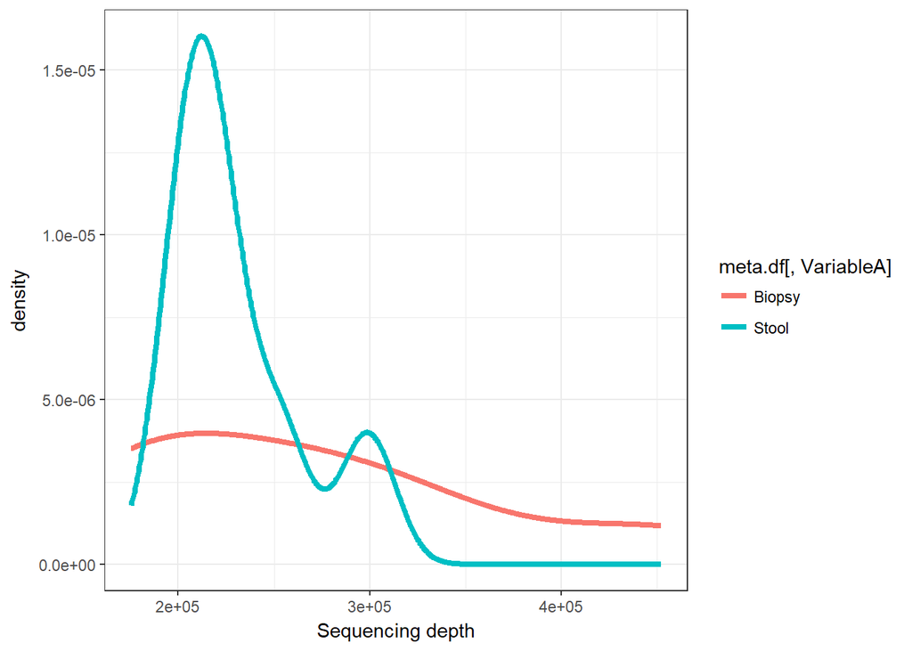

```r
SeqDepth = colSums(otu_table(ps0))
sample_data(ps0)$SeqDepth = SeqDepth
meta.df <- meta(ps0)

qc_plot1 <- ggplot(meta.df, aes(x = SeqDepth, group = meta.df[,VariableA], color = meta.df[,VariableA])) +
  geom_line(size = 1.5, stat = "density") +
  xlab("Sequencing depth") + theme_bw()
print(qc_plot1)
```

```r
ggsave(paste0(out_dir,"/QC/ReadDistribution_density.pdf"))
```

```r
message("QC plots for Read Distribution stored in QC folder as ReadDistribution.pdf")
```

```
## QC plots for Read Distribution stored in QC folder as ReadDistribution.pdf
```

### Library sizes (histogram plot)

```r
message("Investigating library sizes")
```

```
## Investigating library sizes
```

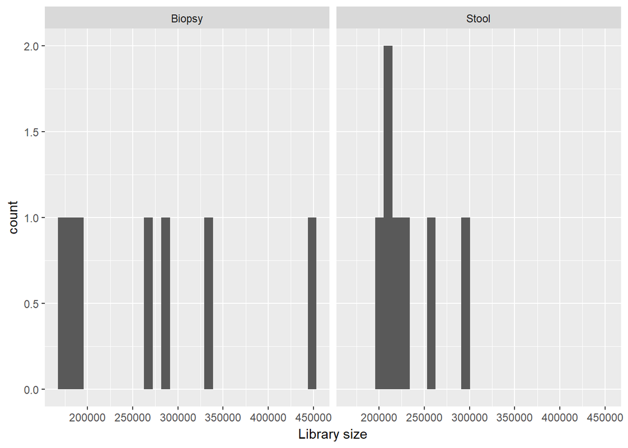

```r
lib.hist <- ggplot(meta.df, aes(x = SeqDepth)) + geom_histogram() +
  facet_wrap(~meta.df[,VariableA]) +
  xlab("Library size")

print(lib.hist)
```

```r
ggsave(paste0(out_dir,"/QC/ReadDistribution_density_hist.pdf"))
message("QC plots for library sizes stored in QC folder as ReadDistribution_density_hist.pdf")
```

```
## QC plots for library sizes stored in QC folder as ReadDistribution_density_hist.pdf
```

*If any sample has less than 2000 reads, it will be removed*

```r
if(min(sample_sums(ps0)) < 2000){
  print("There are sample(s) less than 2000 reads, these will be removed")
  ps0 = prune_samples(sample_sums(ps0)>=2000, ps0)
} else {

  print("No samples below 2000 reads")
  print(ps0)
}
```

```
## [1] "No samples below 2000 reads"
## phyloseq-class experiment-level object
## otu_table()   OTU Table:         [ 19063 taxa and 14 samples ]
## sample_data() Sample Data:       [ 14 samples by 21 sample variables ]
## tax_table()   Taxonomy Table:    [ 19063 taxa by 7 taxonomic ranks ]
```

### OTU counts distribution (density)

```r
message("Investigating OTU counts distribution")
```

```
## Investigating OTU counts distribution
```

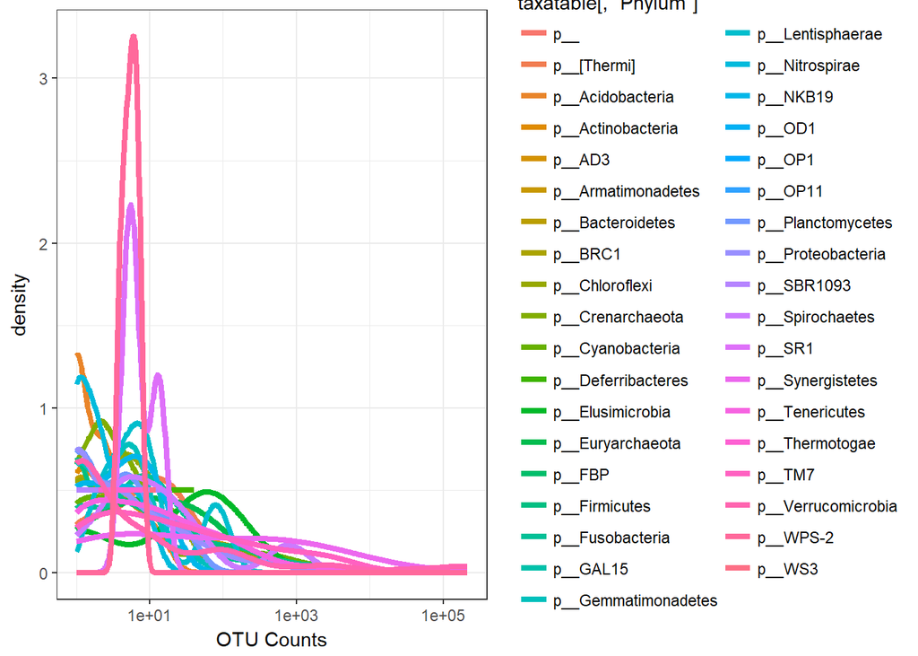

```r
taxasums = rowSums(otu_table(ps0))
taxatable <- as.data.frame.matrix(tax_table(ps0))


tax_plot1 <- ggplot(taxatable, aes(x = taxasums, color = taxatable[,"Phylum"])) +
  geom_line(size = 1.5, stat = "density") +
  xlab("OTU Counts") + theme_bw() + scale_x_log10()
print(tax_plot1)
```

```r
ggsave(paste0(out_dir,"/QC/Distribution_OTU_Counts_by_phyla.pdf"), height = 6, width = 14)
```

### OTU counts distribution (histogram)

```r
message("Investigating OTU counts distribution")
```

```
## Investigating OTU counts distribution
```

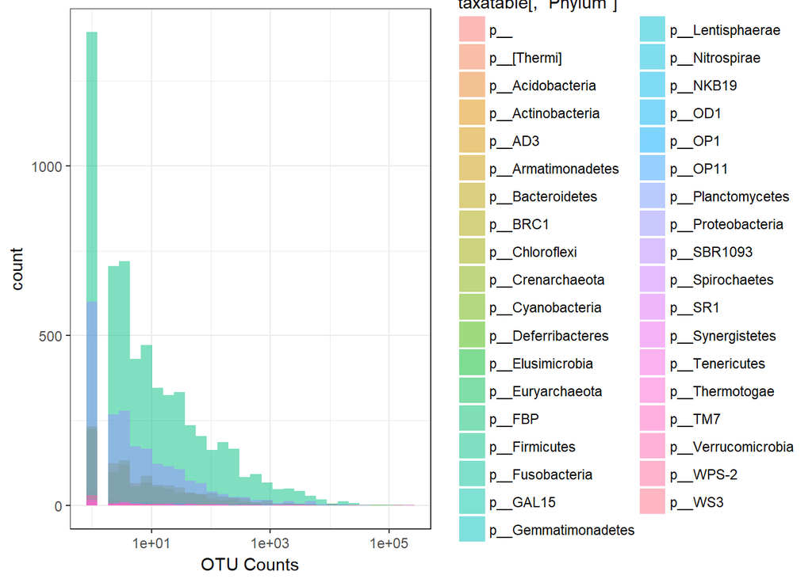

```r
tax_plot2 <- ggplot(taxatable, aes(x = taxasums, fill = taxatable[,"Phylum"])) +
   geom_histogram(bins = 30, alpha = 0.5, position = "identity") +
  xlab("OTU Counts") + theme_bw() + scale_x_log10()
print(tax_plot2)
```

```r
ggsave(paste0(out_dir,"/QC/Distribution_OTU_Counts_by_phyla_hist.pdf"), height = 6, width = 10)
message("QC plots for library sizes stored in QC folder as Distribution_OTU_Counts.pdf")
```

```
## QC plots for library sizes stored in QC folder as Distribution_OTU_Counts.pdf
```

### Taxa prevalence

Check which of the OTUs are present in low abundance and low prevalence. You might want to remove them depending on the research question.

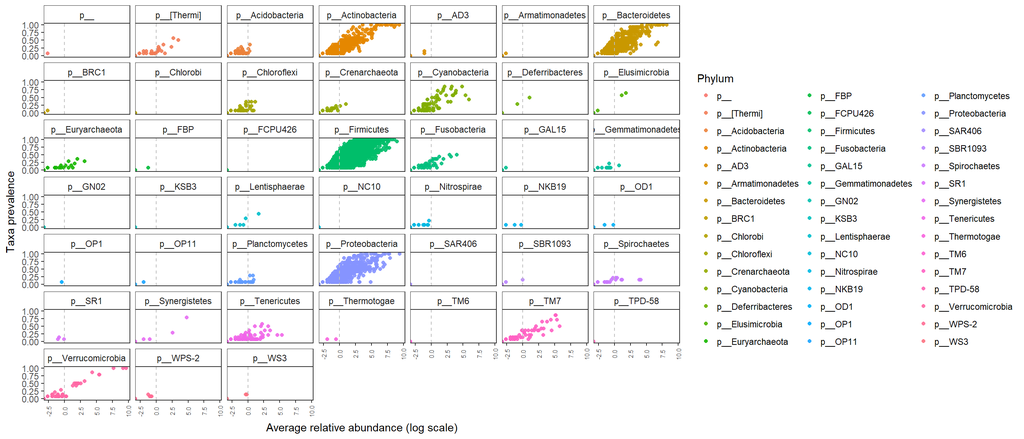

```r
# for sanity
prev.plot <- plot_taxa_prevalence(ps0, "Phylum")
prev.plot
```

```r
ggsave(paste0(out_dir,"/QC/OTU_prevalence_phyla.pdf"), height = 8, width = 16)
```

```r
# for sanity
ps1 <- prune_taxa(taxa_sums(ps0) > 0, ps0)
```

### Variance (raw)

This is variance for all OTU counts without filtering for min number of reads/OTU and prevalence.

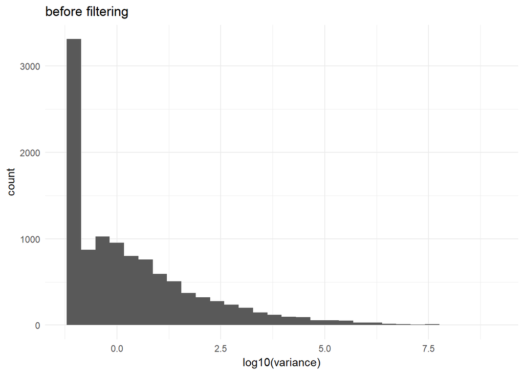

```r
Variance.plot.a <- qplot(log10(apply(otu_table(ps1), 1, var)),
                         xlab = "log10(variance)",
                         main = "Variance in OTUs") +
  ggtitle("before filtering") + theme_minimal()

print(Variance.plot.a)
```

```r
ggsave(paste0(out_dir, "/QC/Variance before filtering.pdf"))
```

```r
message("QC plots for OTU variance stored in QC folder as Variance before filtering.pdf")
```

```
## QC plots for OTU variance stored in QC folder as Variance before filtering.pdf
```

### Variance (filtered)

This is variance for all OTU counts after filtering for min number of reads/OTU and prevalence.

```
## Filtering OTUs with less than 5 counts
```

```
## in at least 1 % of the samples
```

```
## Saving the transformed phyloseq object as ps_filtered.rds
```

```
## Below is the content of filtered phyloseqobject (based on filterCount and filterPrev) stored as ps_filtered.rds
```

```
## phyloseq-class experiment-level object
## otu_table()   OTU Table:         [ 4170 taxa and 14 samples ]
## sample_data() Sample Data:       [ 14 samples by 21 sample variables ]
## tax_table()   Taxonomy Table:    [ 4170 taxa by 7 taxonomic ranks ]
```

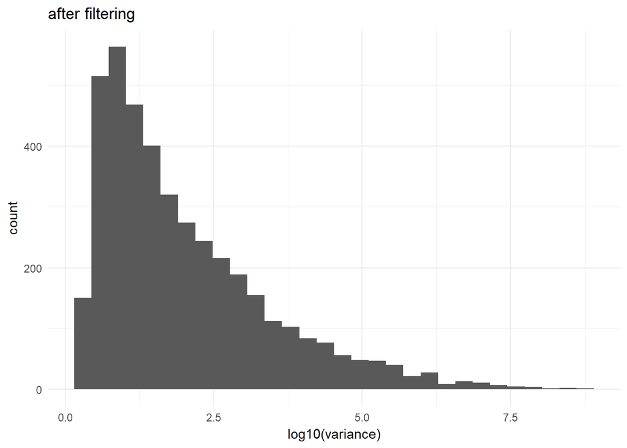

```r
if (filterpseq == TRUE) {
message(paste0("Filtering OTUs with less than ", filterCount, " counts"))
message(paste0("in at least ", filterPrev*100, " % of the samples "))

ps2 = filter_taxa(ps1, function(x) sum(x > filterCount) > (filterPrev * length(x)), TRUE)

message("Saving the transformed phyloseq object as ps_filtered.rds")

saveRDS(ps2, paste0(out_dir,"/PhyloseqObjects/ps_filtered.rds"))

message("Below is the content of filtered phyloseqobject (based on filterCount and filterPrev) stored as ps_filtered.rds")

print(ps2)

Variance.plot.b <- qplot(log10(apply(otu_table(ps2), 1, var)),
                         xlab = "log10(variance)",
                         main = "Variance in OTUs") +
  ggtitle("after filtering") +
  theme_minimal()

print(Variance.plot.b)
ggsave(paste0(out_dir,"/QC/Variance After filtering.pdf"))

} else
  {

    message("filterpseq was false. Did not filter and hence will not save the filtered phyloseq")

    ps2 <- ps1

}
```

## Measuring the kurtosis

Kurtosis is essentially a measure of how much weight is at the tails of the distribution relative to the weight around the location.  
If you have large differences in your library sizes then you may have to normalise your data.

[Kurtosis](http://www.itl.nist.gov/div898/handbook/eda/section3/eda35b.htm)

```r
message("Using the raw phyloseq to check for kurtosis in library size")
```

```
## Using the raw phyloseq to check for kurtosis in library size
```

```r
df <- data.table(NumberReads = sample_sums(ps0), SampleID = sample_names(ps0))
require(moments)
n <- kurtosis(df$NumberReads)

if (n > 3) {
    message("Your library size is heavily tailed, considering normalising them for further analysis")
  }  else {

    message("The variation in library sizes is below kurtosis value of 3 may indicate no need for rarefying")

}
```

```
## Your library size is heavily tailed, considering normalising them for further analysis
```

## Alpha diversity

Alpha diversity measures are standard calculations in microbial ecology. The differences in richness and eveness between groups may have importance to understanding the ecology. There are numerous measures we use the defaults from `microbiome` R package and also the phylogenetic diversity from `picante`R package.

The caculations can be done on rarefied or non-rarefied data which can be specified by the `samsize` option in “Set project attributes” option above.

### Non-phylogenetic diversity measures

For more on this check [**Microbiome:Diversities**](http://microbiome.github.io/microbiome/Diversity.html)

```r
if (!is.na(samsize)) {

  ps3 <- rarefy_even_depth(ps2, sample.size = samsize)

  saveRDS(ps3, paste0(out_dir, "/phyloseqObjects/ps_rarefyied.rds"))
} else{
  ps3 <- ps2
}
```

```
## You set `rngseed` to FALSE. Make sure you've set & recorded
##  the random seed of your session for reproducibility.
## See `?set.seed`
```

```
## ...
```

```
## 1688OTUs were removed because they are no longer
## present in any sample after random subsampling
```

```
## ...
```

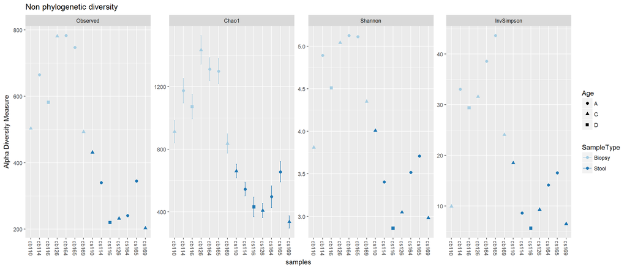

```r
metadf <- meta(ps3)

alpha_div <- plot_richness(ps3,
                           color = VariableA,
                           shape = VariableB,
                           measures = c("Observed", "Chao1", "Shannon", "InvSimpson"))

alpha_div <- alpha_div + geom_point(size = 2) + ggtitle("Non phylogenetic diversity") + scale_color_brewer(palette = col.palette)

print(alpha_div)
```

```r
ggsave(paste0(out_dir,"/AlphaDiversity/Non-phylogenetic_alpha_diversity.pdf"),
              height = 6, width = 18)
if (!is.na(samsize)){
  message("Non-phylogenetic_alpha_diversity on RAREFIED data stored in AlphaDiversity folder")
  message("Non-phylogenetic_alpha_diversity.pdf")
} else{
  message("Non-phylogenetic_alpha_diversity on NON-RAREFIED data stored  in AlphaDiversity folder")
  message("Non-phylogenetic_alpha_diversity.pdf")
}
```

```
## Non-phylogenetic_alpha_diversity on RAREFIED data stored in AlphaDiversity folder
```

```
## Non-phylogenetic_alpha_diversity.pdf
```

### Phylogenetic diversity measures

For more on this check [**Picante**](https://academic.oup.com/bioinformatics/article/26/11/1463/203321/Picante-R-tools-for-integrating-phylogenies-and).

```r
if (!is.na(treefilename)){

  if (!is.na(samsize)) {

  message("Rarefyied phyloseq object will be used to calculate PD")
  print(ps3)
  otu_table_ps3 <- as.data.frame(ps3@otu_table)
 metadata_table_ps3  <- meta(ps3)

 message("include.root in pd is set to FALSE by default")

 df.pd <- pd(t(otu_table_ps3), tree,include.root=F) # t(ou_table) transposes the table for use in picante and the tre file comes from the  first code chunck we used to read tree file (see making a phyloseq object section).


 datatable(df.pd)
# now we need to plot PD
# check above how to get the metadata file from phyloseq object.
# We will add the results of PD to this file and then plot.
 select.meta <- metadata_table_ps3[,c(VariableA,VariableB)] #, "Phyogenetic_diversity"]
 select.meta$Phyogenetic_diversity <- df.pd$PD
 colnames(select.meta) <- c("VariableA", "VariableB", "Phyogenetic_diversity")

 plot.pd <- ggplot(select.meta, aes(VariableA, Phyogenetic_diversity)) + geom_boxplot(aes(fill = VariableB)) + geom_point(size = 2) +  theme(axis.text.x = element_text(size=14, angle = 90))  + theme_bw() + scale_fill_brewer(palette = col.palette)
 print(plot.pd)

 ggsave(paste0(out_dir, "/AlphaDiversity/Phylogenetic_diversityon_nonRafrefied_data.pdf"),
         plot = plot.pd,
         height = 6, width = 18)

} else{

  message("No tree supplied, PD cannot be calculated")

}
}
```

## Micrbial community composition

Having a look at the phyloegnetic composition of you data is useful for many reasons. For this purpose we have two Phylum and Family level plots.

### Phylum (Barplot)

```r
ps3.com <- ps3 # create a new pseq object
# We need to set Palette
taxic <- as.data.frame(ps3.com@tax_table)  # this will help in setting large color options

colourCount = length(unique(taxic$Phylum))  #define number of variable colors based on number of Family (change the level accordingly to phylum/class/order)
getPalette = colorRampPalette(brewer.pal(12, col.palette))  # change the palette as well as the number of colors will change according to palette.

# now edit the unclassified taxa
tax_table(ps3.com)[tax_table(ps3.com)[, "Phylum"] == "f__", "Phylum"] <- "f__Unclassified Phylum"
# We will also remove the 'f__' patterns for cleaner labels
tax_table(ps3.com)[, colnames(tax_table(ps3.com))] <- gsub(tax_table(ps3.com)[,
    colnames(tax_table(ps3.com))], pattern = "[a-z]__", replacement = "")

otu.df <- as.data.frame(otu_table(ps3.com))  # make a dataframe for OTU information.
# head(otu.df) # check the rows and columns

taxic$OTU <- row.names.data.frame(otu.df)  # Add the OTU ids from OTU table into the taxa table at the end.
colnames(taxic)  # You can see that we now have extra taxonomy levels.
```

```
## [1] "Domain"  "Phylum"  "Class"   "Order"   "Family"  "Genus"   "Species"
## [8] "OTU"
```

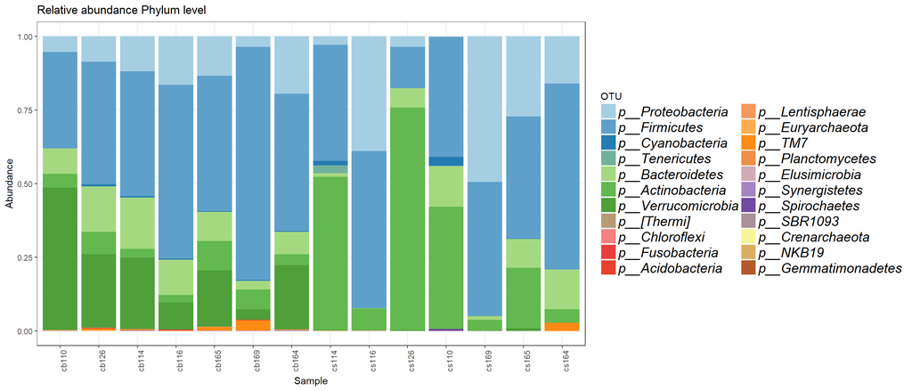

```r
taxmat <- as.matrix(taxic)  # convert it into a matrix.
new.tax <- tax_table(taxmat)  # convert into phyloseq compaitble file.
tax_table(ps3.com) <- new.tax  # incroporate into phyloseq Object


# it would be nice to have the Taxonomic names in italics.
# for that we set this
guide_italics <- guides(fill = guide_legend(label.theme = element_text(size = 15,
    face = "italic", colour = "Black", angle = 0)))


## Now we need to plot at family level, We can do it as follows:

# first remove the phy_tree

ps3.com@phy_tree <- NULL

lev0 = "Phylum"
tax_table(ps3.com)[,lev0][is.na(tax_table(ps3.com)[,lev0])] <- paste0(tolower(substring(lev0, 1, 1)), "__")


ps3.com.phy <- aggregate_taxa(ps3.com, "Phylum")

ps3.com.phy.rel <- microbiome::transform(ps3.com.phy, "compositional")

plot.composition.relAbun.phy <- plot_composition(ps3.com.phy.rel) + theme(legend.position = "bottom") +
    scale_fill_manual(values = getPalette(colourCount)) + theme_bw() +
    theme(axis.text.x = element_text(angle = 90)) +
  ggtitle("Relative abundance Phylum level") + guide_italics

plot.composition.relAbun.phy
```

```r
if (nrow(metadf) > 30) {
  ggsave(paste0(out_dir, "/Others/compositionbarplot_Phylum.pdf"), plot = plot.composition.relAbun.phy, height = 8, width = 28)

} else {
    ggsave(paste0(out_dir, "/Others/compositionbarplot_Phylum.pdf"), plot = plot.composition.relAbun.phy,
      height = 8, width = 18)
}
```

### Phylum (Boxplot)

```
## The phy_tree slot is empty, easy to make the plot
```

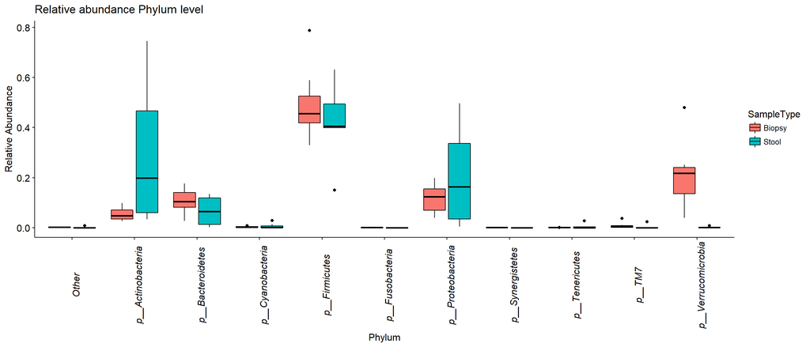

```r
pn0 <- plot_taxa_boxplot(ps1,
                        taxonomic.level = "Phylum",
                        top.otu = 10, VariableA,
                        title = "Relative abundance Phylum level")
```

```r
ggsave(paste0(out_dir,"/Others/compositionboxplot_Phylum.pdf"), height = 6, width = 12)
```

### Family (Barplot)

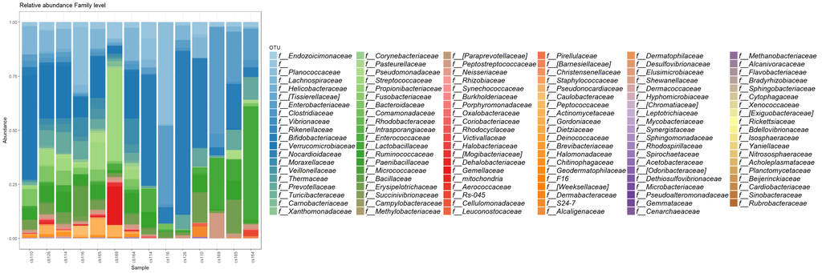

```r
colourCount = length(unique(taxic$Family))  #define number of variable colors based on number of Family (change the level accordingly to phylum/class/order)
getPalette = colorRampPalette(brewer.pal(12, col.palette))  # change the palette as well as the number of colors will change according to palette.
lev = "Family"
tax_table(ps3.com)[,lev][is.na(tax_table(ps3.com)[,lev])] <- paste0(tolower(substring(lev, 1, 1)), "__")

ps3.com.fam <- aggregate_taxa(ps3.com, "Family")

ps3.com.fam.rel <- microbiome::transform(ps3.com.fam, "compositional")

plot.composition.relAbun.fam <- plot_composition(ps3.com.fam.rel) + theme(legend.position = "bottom") +
    scale_fill_manual(values = getPalette(colourCount)) + theme_bw() +
    theme(axis.text.x = element_text(angle = 90)) +
  ggtitle("Relative abundance Family level") + guide_italics

plot.composition.relAbun.fam
```

```r
if (nrow(metadf) > 30) {
  ggsave(paste0(out_dir,"/Others/compositionbarplot_Family.pdf"), plot = plot.composition.relAbun.fam, height = 8, width = 28)

} else {
    ggsave(paste0(out_dir,"/Others/compositionbarplot_Family.pdf"), plot = plot.composition.relAbun.fam,
      height = 8, width = 18)
}
```

### Family (Boxplot)

Top 10 Families are shown below:

```
## The phy_tree slot is empty, easy to make the plot
```

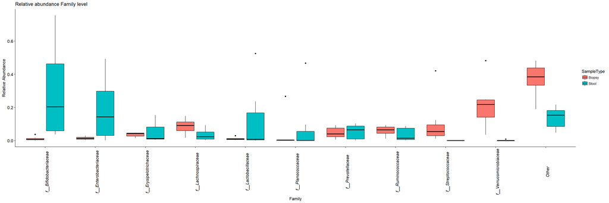

```r
pn1 <- plot_taxa_boxplot(ps3.com,
                        taxonomic.level = "Family",
                        top.otu = 10, VariableA,
                        title = "Relative abundance Family level")
```

```r
ggsave(paste0(out_dir,"/Others/compositionboxplot_Family.pdf"), height = 6, width = 16)
```

## Beta Diversity (Ordinations)

### Bray-Curtis distance PCoA

The counts are compositionally tranformed and then used for ordinations.

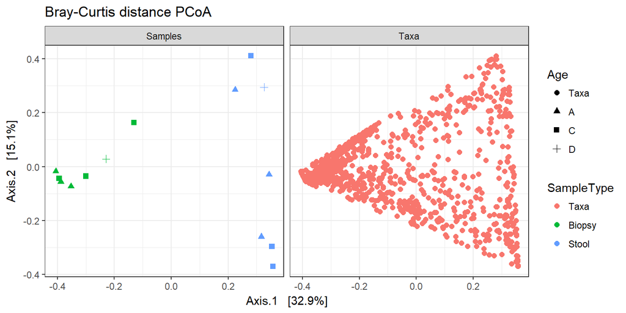

```r
ps3.rel <- microbiome::transform(ps3, "compositional")

bc.pcoa <- ordinate(ps3.rel, method = "PCoA", distance = "bray")

bc.pcoa.plot <- plot_ordination(ps3.rel, bc.pcoa,
                                type = "split", axes = 1:2,
                                color = VariableA, shape = VariableB,
                                label = NULL,
                                title = "Bray-Curtis distance PCoA",
                                justDF = FALSE)
bc.pcoa.plot <- bc.pcoa.plot + theme_bw() + geom_point(size = 2)
print(bc.pcoa.plot)
```

```r
ggsave(paste0(out_dir,"/BetaDiversity/Bray-Curtis distance PCoA.pdf"), plot = bc.pcoa.plot,
      height = 6, width = 10)


# Calculate bray curtis distance matrix
ps3_bray <- phyloseq::distance(ps3.rel, method = "bray")

# use meta data from phylogenetic div code chunk.
metadata_table_ps3  <- meta(ps3.rel)
select.meta2 <- metadata_table_ps3[,c(VariableA,VariableB)] #, "Phyogenetic_diversity"]

colnames(select.meta2) <- c("VariableA", "VariableB")

# Adonis test
adonis(ps3_bray ~ VariableA, data = select.meta2)
```

```
##
## Call:
## adonis(formula = ps3_bray ~ VariableA, data = select.meta2)
##
## Permutation: free
## Number of permutations: 999
##
## Terms added sequentially (first to last)
##
##           Df SumsOfSqs MeanSqs F.Model      R2 Pr(>F)
## VariableA  1    1.4044 1.40441  5.5596 0.31661  0.001 ***
## Residuals 12    3.0313 0.25261         0.68339
## Total     13    4.4357                 1.00000
## ---
## Signif. codes:  0 '***' 0.001 '**' 0.01 '*' 0.05 '.' 0.1 ' ' 1
```

```r
# Homogeneity of dispersion test
beta.bray <- betadisper(ps3_bray, select.meta2$VariableA)
permutest(beta.bray)
```

```
##
## Permutation test for homogeneity of multivariate dispersions
## Permutation: free
## Number of permutations: 999
##
## Response: Distances
##           Df  Sum Sq  Mean Sq      F N.Perm Pr(>F)
## Groups     1 0.07546 0.075455 2.7754    999  0.133
## Residuals 12 0.32625 0.027187
```

### Weighted Unifrac distance PCoA

The counts are converted to relative abundance and then used for ordinations.

```r
if (!is.na(treefilename)){

wunifrac.pcoa <- ordinate(ps3.rel, method = "PCoA", distance = "wunifrac")

wunifrac.pcoa.plot <- plot_ordination(ps3.rel, wunifrac.pcoa,
                                type = "split", axes = 1:2,
                                color = VariableA, shape = VariableB,
                                label = NULL,
                                title = "Weighted Unifrac distance PCoA",
                                justDF = FALSE)
wunifrac.pcoa.plot <- wunifrac.pcoa.plot + theme_bw() + geom_point(size = 2)
print(wunifrac.pcoa.plot)

ggsave(paste0(out_dir,"/BetaDiversity/Weighted Unifrac distance PCoA.pdf"), plot = wunifrac.pcoa.plot,
      height = 6, width = 10)

# Calculate bray curtis distance matrix
ps3_wunifrac <- phyloseq::distance(ps3.rel, method = "wunifrac")

# use meta data from phylogenetic div code chunk.

# Adonis test
adonis(ps3_wunifrac ~ VariableA, data = select.meta2)


# Homogeneity of dispersion test
beta.wunifrac <- betadisper(ps3_wunifrac, select.meta2$VariableA)
permutest(beta.wunifrac)
} else {
  message("No tree supplied, cannot calculate unifrac distances")
}
```

```
## No tree supplied, cannot calculate unifrac distances
```